# Untitled

2023-09-27

```r
knitr::opts_chunk$set(warning = FALSE)

source('code/helpers.R')

library(tidyverse)
```

```r
data <- targets::tar_read(truth_set_data)
blast <- targets::tar_read(subsambled_blast_hits_data)
kraken <- targets::tar_read(subsambled_kraken_hits_data)

kraken <- kraken |> separate(Type, c('Type', 'Kraken_confidence'), sep = '_') |>
  mutate(Kraken_confidence = as.numeric(Kraken_confidence))


kraken_0.1 <- kraken |> filter(Kraken_confidence == 0.1)
kraken <- kraken |> filter(Kraken_confidence == 0.0)
nbc <- targets::tar_read(subsampled_nbc_hits_data)
```

```r
data |> mutate(species = case_when(species != 'dropped' ~ 'OnSpeciesLevel',
                                   TRUE ~ 'OnGenusLevel')) |>
  count(species)
```

```
## # A tibble: 2 × 2
##   species            n
##   <chr>          <int>
## 1 OnGenusLevel      22
## 2 OnSpeciesLevel   679
```

```r
blast |> right_join(data, by = c('Query','OTU'), suffix = c('Blast', 'Truth')) |>
  select(speciesBlast, speciesTruth) |>
  filter(speciesBlast != 'dropped',
         speciesTruth != 'dropped') |>
  mutate(same = speciesBlast == speciesTruth) |> select(same) |> table()
```

```
## same
## FALSE  TRUE
##    13    96
```

True negatives:

```r
blast |> right_join(data, by = c('Query','OTU'), suffix = c('Blast', 'Truth')) |>
  select(speciesBlast, speciesTruth) |>
  filter(speciesBlast %in% c(NA, 'dropped'),
         speciesTruth == 'dropped')
```

```
## # A tibble: 22 × 2
##    speciesBlast speciesTruth
##    <chr>        <chr>
##  1 <NA>         dropped
##  2 <NA>         dropped
##  3 <NA>         dropped
##  4 <NA>         dropped
##  5 <NA>         dropped
##  6 <NA>         dropped
##  7 <NA>         dropped
##  8 <NA>         dropped
##  9 <NA>         dropped
## 10 <NA>         dropped
## # ℹ 12 more rows
```

false negatives:

```r
blast |> right_join(data, by = c('Query','OTU'), suffix = c('Blast', 'Truth')) |>
  select(speciesBlast, speciesTruth) |>
  filter(speciesBlast %in% c(NA, 'dropped'),
         speciesTruth != 'dropped')
```

```
## # A tibble: 570 × 2
##    speciesBlast speciesTruth
##    <chr>        <chr>
##  1 dropped      Ctenochaetus tominiensis
##  2 dropped      Alepocephalus umbriceps
##  3 dropped      Cheilopogon unicolor
##  4 dropped      Cirripectes castaneus
##  5 dropped      Trachurus japonicus
##  6 dropped      Maccullochella peelii
##  7 dropped      Alosa aestivalis
##  8 dropped      Sardinella jussieu
##  9 dropped      Anguilla marmorata
## 10 dropped      Lentipes kijimuna
## # ℹ 560 more rows
```

```r
blast |> right_join(data, by = c('Query','OTU'), suffix = c('Blast', 'Truth')) |> nrow()
```

```
## [1] 701
```

So we have 137 false negatives, 96 true positives, 13 false positives, 3 true negatives.

```r
blast_accuracy <- 96 / (249)
blast_precision <- 96 / (96 + 13)
blast_recall <- 96 / (96 + 137)
blast_f1 <- 2 * (blast_precision * blast_recall) / (blast_precision + blast_recall)
blast_f0.5 <- 1.25 * ( blast_precision * blast_recall / (0.25 * blast_precision + blast_recall))
```

# Kraken

For Kraken:

```r
kraken |> right_join(data, by = c('Query','OTU'), suffix = c('Kraken', 'Truth'))
```

```
## # A tibble: 701 × 23
##    Type   Kraken_confidence Query        SubjectKraken domainKraken phylumKraken
##    <chr>              <dbl> <chr>        <chr>         <chr>        <chr>
##  1 Kraken                 0 make_12s_16… 12s_v010_fin… Eukaryota    Chordata
##  2 Kraken                 0 make_12s_16… 12s_v010_fin… Eukaryota    Chordata
##  3 Kraken                 0 make_12s_16… 12s_v010_fin… Eukaryota    Chordata
##  4 Kraken                 0 make_12s_16… 12s_v010_fin… Eukaryota    Chordata
##  5 Kraken                 0 make_12s_16… 12s_v010_fin… Eukaryota    Chordata
##  6 Kraken                 0 make_12s_16… 12s_v010_fin… Eukaryota    Chordata
##  7 Kraken                 0 make_12s_16… 12s_v010_fin… Eukaryota    Chordata
##  8 Kraken                 0 make_12s_16… 12s_v010_fin… Eukaryota    Chordata
##  9 Kraken                 0 make_12s_16… 12s_v010_fin… Eukaryota    Chordata
## 10 Kraken                 0 make_12s_16… 12s_v010_fin… Eukaryota    Chordata
## # ℹ 691 more rows
## # ℹ 17 more variables: classKraken <chr>, orderKraken <chr>,
## #   familyKraken <chr>, genusKraken <chr>, speciesKraken <chr>, OTU <chr>,
## #   SubjectTruth <chr>, taxids <chr>, lca_taxid <dbl>, long_lineage <chr>,
## #   domainTruth <chr>, phylumTruth <chr>, classTruth <chr>, orderTruth <chr>,
## #   familyTruth <chr>, genusTruth <chr>, speciesTruth <chr>
```

True positives, False positives:

```r
kraken |> right_join(data, by = c('Query','OTU'), suffix = c('Kraken', 'Truth')) |>
  select(speciesKraken, speciesTruth) |>
  filter(!is.na(speciesKraken),
         speciesTruth != 'dropped') |>
  mutate(same = speciesKraken == speciesTruth) |> select(same) |> table()
```

```
## same
## FALSE  TRUE
##    29   106
```

True Negatives:

```r
kraken |> right_join(data, by = c('Query','OTU'), suffix = c('Kraken', 'Truth')) |>
  select(speciesKraken, speciesTruth) |>
  filter(is.na(speciesKraken),
         speciesTruth == 'dropped')
```

```
## # A tibble: 22 × 2
##    speciesKraken speciesTruth
##    <chr>         <chr>
##  1 <NA>          dropped
##  2 <NA>          dropped
##  3 <NA>          dropped
##  4 <NA>          dropped
##  5 <NA>          dropped
##  6 <NA>          dropped
##  7 <NA>          dropped
##  8 <NA>          dropped
##  9 <NA>          dropped
## 10 <NA>          dropped
## # ℹ 12 more rows
```

False negatives:

```r
kraken |> right_join(data, by = c('Query','OTU'), suffix = c('Kraken', 'Truth')) |>
  select(speciesKraken, speciesTruth) |>
  filter(is.na(speciesKraken),
         speciesTruth != 'dropped')
```

```
## # A tibble: 544 × 2
##    speciesKraken speciesTruth
##    <chr>         <chr>
##  1 <NA>          Alepocephalus umbriceps
##  2 <NA>          Anguilla marmorata
##  3 <NA>          Cheilopogon unicolor
##  4 <NA>          Cirripectes castaneus
##  5 <NA>          Trachurus japonicus
##  6 <NA>          Maccullochella peelii
##  7 <NA>          Alosa aestivalis
##  8 <NA>          Sardinella jussieu
##  9 <NA>          Lentipes kijimuna
## 10 <NA>          Rhinogobius brunneus
## # ℹ 534 more rows
```

106 True positives, 29 False Positives, 3 true negatives, 111 false negatives

```r
kraken_accuracy <- 106 / (106+29+3+111)
kraken_precision <- 106 / (106 + 29)
kraken_recall <- 106 / (106 + 111)
kraken_f1 <- 2 * (kraken_precision * kraken_recall) / (kraken_precision + kraken_recall)
kraken_f0.5 <- 1.25 * ( kraken_precision * kraken_recall / (0.25 * kraken_precision + kraken_recall))
```

# Kraken 0.1

True positives, False positives:

```r
kraken_0.1 |> right_join(data, by = c('Query','OTU'), suffix = c('Kraken', 'Truth')) |>
  select(speciesKraken, speciesTruth) |>
  filter(!is.na(speciesKraken),
         speciesTruth != 'dropped') |>
  mutate(same = speciesKraken == speciesTruth) |> select(same) |> table()
```

```
## same
## FALSE  TRUE
##    15    92
```

True Negatives:

```r
kraken_0.1 |> right_join(data, by = c('Query','OTU'), suffix = c('Kraken', 'Truth')) |>
  select(speciesKraken, speciesTruth) |>
  filter(is.na(speciesKraken),
         speciesTruth == 'dropped')
```

```
## # A tibble: 22 × 2
##    speciesKraken speciesTruth
##    <chr>         <chr>
##  1 <NA>          dropped
##  2 <NA>          dropped
##  3 <NA>          dropped
##  4 <NA>          dropped
##  5 <NA>          dropped
##  6 <NA>          dropped
##  7 <NA>          dropped
##  8 <NA>          dropped
##  9 <NA>          dropped
## 10 <NA>          dropped
## # ℹ 12 more rows
```

False negatives:

```r
kraken_0.1 |> right_join(data, by = c('Query','OTU'), suffix = c('Kraken', 'Truth')) |>
  select(speciesKraken, speciesTruth) |>
  filter(is.na(speciesKraken),
         speciesTruth != 'dropped')
```

```
## # A tibble: 572 × 2
##    speciesKraken speciesTruth
##    <chr>         <chr>
##  1 <NA>          Ctenochaetus tominiensis
##  2 <NA>          Alepocephalus umbriceps
##  3 <NA>          Anguilla marmorata
##  4 <NA>          Cheilopogon unicolor
##  5 <NA>          Cirripectes castaneus
##  6 <NA>          Trachurus japonicus
##  7 <NA>          Tilodon sexfasciatus
##  8 <NA>          Maccullochella peelii
##  9 <NA>          Alosa aestivalis
## 10 <NA>          Sardinella jussieu
## # ℹ 562 more rows
```

92 True positives, 15 False Positives, 3 true negatives, 139 false negatives

```r
kraken_0.1_accuracy <- 92 / (92+15+3+139)
kraken_0.1_precision <- 92 / (92 + 15)
kraken_0.1_recall <- 92/ (92 + 139)
kraken_0.1_f1 <- 2 * (kraken_0.1_precision * kraken_0.1_recall) / (kraken_0.1_precision + kraken_0.1_recall)
kraken_0.1_mcc <- (92*3 - 15*139) / sqrt((92+15) * (92 + 139) * (3 + 15) * (3 + 139))
kraken_0.1_f0.5 <- 1.25 * ( kraken_0.1_precision * kraken_0.1_recall / (0.25 * kraken_0.1_precision + kraken_0.1_recall))
```

# NBC

```r
nbc |>
  right_join(data, by = c('Query','OTU'), suffix = c('Kraken', 'Truth'))
```

```
## # A tibble: 701 × 22
##    Type    Query SubjectKraken domainKraken phylumKraken classKraken orderKraken
##    <chr>   <chr> <chr>         <lgl>        <lgl>        <lgl>       <lgl>
##  1 Custom… make… 12s_v010_fin… NA           NA           NA          NA
##  2 Custom… make… 12s_v010_fin… NA           NA           NA          NA
##  3 Custom… make… 12s_v010_fin… NA           NA           NA          NA
##  4 Custom… make… 12s_v010_fin… NA           NA           NA          NA
##  5 Custom… make… 12s_v010_fin… NA           NA           NA          NA
##  6 Custom… make… 12s_v010_fin… NA           NA           NA          NA
##  7 Custom… make… 12s_v010_fin… NA           NA           NA          NA
##  8 Custom… make… 12s_v010_fin… NA           NA           NA          NA
##  9 Custom… make… 12s_v010_fin… NA           NA           NA          NA
## 10 Custom… make… 12s_v010_fin… NA           NA           NA          NA
## # ℹ 691 more rows
## # ℹ 15 more variables: familyKraken <lgl>, genusKraken <chr>,
## #   speciesKraken <chr>, OTU <chr>, SubjectTruth <chr>, taxids <chr>,
## #   lca_taxid <dbl>, long_lineage <chr>, domainTruth <chr>, phylumTruth <chr>,
## #   classTruth <chr>, orderTruth <chr>, familyTruth <chr>, genusTruth <chr>,
## #   speciesTruth <chr>
```

True positives, False positives:

```r
nbc |> right_join(data, by = c('Query','OTU'), suffix = c('NBC', 'Truth')) |>
  select(speciesNBC, speciesTruth) |>
  filter(!is.na(speciesNBC),
         speciesTruth != 'dropped') |>
  mutate(same = speciesNBC == speciesTruth) |> select(same) |> table()
```

[output not shown]

True Negatives:

```r
nbc |> right_join(data, by = c('Query','OTU'), suffix = c('NBC', 'Truth')) |>
  select(speciesNBC, speciesTruth) |>
  filter(is.na(speciesNBC),
         speciesTruth == 'dropped')
```

```
## # A tibble: 22 × 2
##    speciesNBC speciesTruth
##    <chr>      <chr>
##  1 <NA>       dropped
##  2 <NA>       dropped
##  3 <NA>       dropped
##  4 <NA>       dropped
##  5 <NA>       dropped
##  6 <NA>       dropped
##  7 <NA>       dropped
##  8 <NA>       dropped
##  9 <NA>       dropped
## 10 <NA>       dropped
## # ℹ 12 more rows
```

False negatives:

```r
nbc |> right_join(data, by = c('Query','OTU'), suffix = c('NBC', 'Truth')) |>
  select(speciesNBC, speciesTruth) |>
  filter(is.na(speciesNBC),
         speciesTruth != 'dropped')
```

```
## # A tibble: 556 × 2
##    speciesNBC speciesTruth
##    <chr>      <chr>
##  1 <NA>       Phyllopteryx taeniolatus
##  2 <NA>       Carcharhinus brachyurus
##  3 <NA>       Ctenochaetus tominiensis
##  4 <NA>       Glyphis garricki
##  5 <NA>       Cheilopogon unicolor
##  6 <NA>       Plestiodon chinensis
##  7 <NA>       Cleisthenes herzensteini
##  8 <NA>       Holacanthus ciliaris
##  9 <NA>       Pristis pectinata
## 10 <NA>       Himantura microphthalma
## # ℹ 546 more rows
```

```r
nbc_accuracy <- 96 / (96+31+3+119)
nbc_precision <- 96 / (96 + 31)
nbc_recall <- 96 / (96 + 119)
nbc_f1 <- 2 * (nbc_precision * nbc_recall) / (nbc_precision + nbc_recall)
nbc_mcc <- (96*3 - 31*119) / sqrt((96 + 31) * (96 + 119) * (3 + 31) * (3 + 119))
nbc_f0.5 <- 1.25 * ( nbc_precision * nbc_recall / (0.25 * nbc_precision + nbc_recall))
```

# summary

```r
df <- tibble(names = c('blast', 'kraken', 'kraken_0.1', 'nbc'), f1 = c(blast_f1, kraken_f1, kraken_0.1_f1, nbc_f1), f0.5 = c(blast_f0.5, kraken_f0.5, kraken_0.1_f0.5, nbc_f0.5), recall = c(blast_recall, kraken_recall, kraken_0.1_recall, nbc_recall), accuracy = c(blast_accuracy, kraken_accuracy, kraken_0.1_accuracy, nbc_accuracy), precision = c(blast_precision, kraken_precision, kraken_0.1_precision, nbc_precision))
df
```

```
## # A tibble: 4 × 6
##   names         f1  f0.5 recall accuracy precision
##   <chr>      <dbl> <dbl>  <dbl>    <dbl>     <dbl>
## 1 blast      0.561 0.717  0.412    0.386     0.881
## 2 kraken     0.602 0.700  0.488    0.426     0.785
## 3 kraken_0.1 0.544 0.698  0.398    0.369     0.860
## 4 nbc        0.561 0.664  0.447    0.386     0.756
```

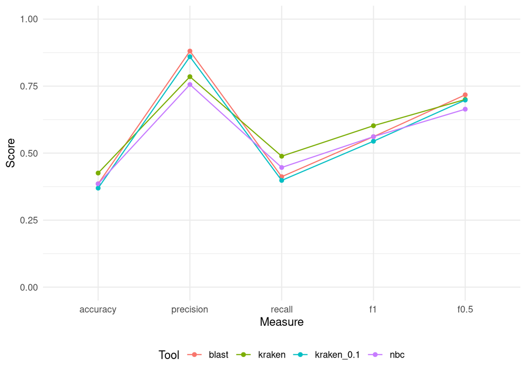

```r
df |> pivot_longer(-names, names_to = 'Measure', values_to='Score') |>
  rename(Tool = names) |>
  ggplot(aes(x = factor(Measure, levels=c('accuracy', 'precision', 'recall', 'f1', 'f0.5')),  color = Tool, fill = Tool, y = Score, group = Tool)) + geom_point() + geom_line() +
  ylim(c(0, 1)) + theme_minimal() + theme(legend.position="bottom") + xlab('Measure')
```

```r
kraken_0.1 |> right_join(data, by = c('Query','OTU'), suffix = c('Kraken_0.1', 'Truth')) |>
  mutate(Type = str_replace(Type, 'Kraken', replacement = 'Kraken_0.1')) |>
  right_join(kraken |> select(Query, OTU, species), by = c('Query', 'OTU')) |>
  rename(species_Kraken = species) |>
  right_join(blast |> select(Query, OTU, species), by = c('Query', 'OTU')) |>
  rename(species_Blast = species) |> select(speciesTruth, speciesKraken_0.1, species_Kraken, species_Blast) |>
  mutate(species_Blast = na_if(species_Blast, 'dropped'))
```

```
## # A tibble: 183 × 4
##    speciesTruth             speciesKraken_0.1       species_Kraken species_Blast
##    <chr>                    <chr>                   <chr>          <chr>
##  1 Ctenochaetus tominiensis <NA>                    Ctenochaetus … <NA>
##  2 Stereolepis doederleini  Stereolepis doederleini Stereolepis d… Stereolepis …
##  3 Alepocephalus umbriceps  <NA>                    <NA>           <NA>
##  4 Anguilla marmorata       <NA>                    <NA>           <NA>
##  5 Gymnothorax javanicus    Gymnothorax javanicus   Gymnothorax j… Gymnothorax …
##  6 Nettastoma parviceps     Nettastoma parviceps    Nettastoma pa… Nettastoma p…
##  7 Atherinomorus stipes     Atherinomorus stipes    Atherinomorus… Atherinomoru…
##  8 Saurida wanieso          Saurida wanieso         Saurida wanie… Saurida wani…
##  9 Cheilopogon unicolor     <NA>                    <NA>           <NA>
## 10 Cirripectes castaneus    <NA>                    <NA>           <NA>
## # ℹ 173 more rows
```

# MORE

```r
data <- targets::tar_read(truth_set_data)
blast_thirty <- targets::tar_read(thirty_subsambled_blast_hits_data)
kraken_thirty <- targets::tar_read(thirty_subsampled_kraken_hits_data)

kraken_thirty <- kraken_thirty |> separate(Type, c('Type', 'Kraken_confidence'), sep='_') |>
  mutate(Kraken_confidence = as.numeric(Kraken_confidence))

kraken_0.1_thirty <- kraken_thirty |> filter(Kraken_confidence == 0.1)
kraken_thirty <-  kraken_thirty |> filter(Kraken_confidence == 0.0)
nbc_thirty <- targets::tar_read(thirty_subsampled_nbc_hits_data)
```

```r
data |> mutate(species = case_when(species != 'dropped' ~ 'OnSpeciesLevel',
                                   TRUE ~ 'OnGenusLevel')) |>
  count(species)
```

```
## # A tibble: 2 × 2
##   species            n
##   <chr>          <int>
## 1 OnGenusLevel      22
## 2 OnSpeciesLevel   679
```

```r
blast_thirty |> right_join(data, by = c('Query','OTU'), suffix = c('Blast', 'Truth')) |>
  select(speciesBlast, speciesTruth) |>
  filter(speciesBlast != 'dropped',
         speciesTruth != 'dropped') |>
  mutate(same = speciesBlast == speciesTruth) |> select(same) |> table()
```

```
## same
## FALSE  TRUE
##     6    27
```

True negatives:

```r
blast_thirty |> right_join(data, by = c('Query','OTU'), suffix = c('Blast', 'Truth')) |>
  select(speciesBlast, speciesTruth) |>
  filter(speciesBlast %in% c(NA, 'dropped'),
         speciesTruth == 'dropped')
```

```
## # A tibble: 22 × 2
##    speciesBlast speciesTruth
##    <chr>        <chr>
##  1 <NA>         dropped
##  2 <NA>         dropped
##  3 <NA>         dropped
##  4 <NA>         dropped
##  5 <NA>         dropped
##  6 <NA>         dropped
##  7 <NA>         dropped
##  8 <NA>         dropped
##  9 <NA>         dropped
## 10 <NA>         dropped
## # ℹ 12 more rows
```

false negatives:

```r
blast_thirty |> right_join(data, by = c('Query','OTU'), suffix = c('Blast', 'Truth')) |>
  select(speciesBlast, speciesTruth) |>
  filter(speciesBlast %in% c(NA, 'dropped'),
         speciesTruth != 'dropped')
```

```
## # A tibble: 646 × 2
##    speciesBlast speciesTruth
##    <chr>        <chr>
##  1 dropped      Ctenochaetus tominiensis
##  2 dropped      Istiophorus platypterus
##  3 dropped      Eutrigla gurnardus
##  4 dropped      Cleisthenes herzensteini
##  5 dropped      Auxis rochei
##  6 dropped      Syngnathus pelagicus
##  7 dropped      Hippocampus kuda
##  8 dropped      Xanthichthys auromarginatus
##  9 dropped      Ostracion rhinorhynchos
## 10 dropped      Aythya nyroca
## # ℹ 636 more rows
```

```r
blast_thirty |> right_join(data, by = c('Query','OTU'), suffix = c('Blast', 'Truth')) |> nrow()
```

```
## [1] 701
```

So we have 213 false negatives, 27 true positives, 6 false positives, 3 true negatives.

```r
blast_accuracy <- 27 / (249)
blast_precision <- 27 / (27 + 6)
blast_recall <- 27 / (27 + 213)
blast_f1 <- 2 * (blast_precision * blast_recall) / (blast_precision + blast_recall)
blast_f0.5 <- 1.25 * ( blast_precision * blast_recall / (0.25 * blast_precision + blast_recall))
```

# Kraken

For Kraken:

```r
kraken_thirty |> right_join(data, by = c('Query','OTU'), suffix = c('Kraken', 'Truth'))
```

```
## # A tibble: 701 × 23
##    Type   Kraken_confidence Query        SubjectKraken domainKraken phylumKraken
##    <chr>              <dbl> <chr>        <chr>         <chr>        <chr>
##  1 Kraken                 0 make_12s_16… 12s_v010_fin… Eukaryota    Chordata
##  2 Kraken                 0 make_12s_16… 12s_v010_fin… Eukaryota    Chordata
##  3 Kraken                 0 make_12s_16… 12s_v010_fin… Eukaryota    Chordata
##  4 Kraken                 0 make_12s_16… 12s_v010_fin… Eukaryota    Chordata
##  5 Kraken                 0 make_12s_16… 12s_v010_fin… Eukaryota    Chordata
##  6 Kraken                 0 make_12s_16… 12s_v010_fin… Eukaryota    Chordata
##  7 Kraken                 0 make_12s_16… 12s_v010_fin… Eukaryota    Chordata
##  8 Kraken                 0 make_12s_16… 12s_v010_fin… Eukaryota    Chordata
##  9 Kraken                 0 make_12s_16… 12s_v010_fin… Eukaryota    Chordata
## 10 Kraken                 0 make_12s_16… 12s_v010_fin… Eukaryota    Chordata
## # ℹ 691 more rows
## # ℹ 17 more variables: classKraken <chr>, orderKraken <chr>,
## #   familyKraken <chr>, genusKraken <chr>, speciesKraken <chr>, OTU <chr>,
## #   SubjectTruth <chr>, taxids <chr>, lca_taxid <dbl>, long_lineage <chr>,
## #   domainTruth <chr>, phylumTruth <chr>, classTruth <chr>, orderTruth <chr>,
## #   familyTruth <chr>, genusTruth <chr>, speciesTruth <chr>
```

True positives, False positives:

```r
kraken_thirty |> right_join(data, by = c('Query','OTU'), suffix = c('Kraken', 'Truth')) |>
  select(speciesKraken, speciesTruth) |>
  filter(!is.na(speciesKraken),
         speciesTruth != 'dropped') |>
  mutate(same = speciesKraken == speciesTruth) |> select(same) |> table()
```

```
## same
## FALSE  TRUE
##    65    33
```

True Negatives:

```r
kraken_thirty |> right_join(data, by = c('Query','OTU'), suffix = c('Kraken', 'Truth')) |>
  select(speciesKraken, speciesTruth) |>
  filter(is.na(speciesKraken),
         speciesTruth == 'dropped')
```

```
## # A tibble: 22 × 2
##    speciesKraken speciesTruth
##    <chr>         <chr>
##  1 <NA>          dropped
##  2 <NA>          dropped
##  3 <NA>          dropped
##  4 <NA>          dropped
##  5 <NA>          dropped
##  6 <NA>          dropped
##  7 <NA>          dropped
##  8 <NA>          dropped
##  9 <NA>          dropped
## 10 <NA>          dropped
## # ℹ 12 more rows
```

False negatives:

```r
kraken_thirty |> right_join(data, by = c('Query','OTU'), suffix = c('Kraken', 'Truth')) |>
  select(speciesKraken, speciesTruth) |>
  filter(is.na(speciesKraken),
         speciesTruth != 'dropped')
```

```
## # A tibble: 581 × 2
##    speciesKraken speciesTruth
##    <chr>         <chr>
##  1 <NA>          Myoxocephalus quadricornis
##  2 <NA>          Istiophorus platypterus
##  3 <NA>          Cheilinus undulatus
##  4 <NA>          Rhinogobius brunneus
##  5 <NA>          Holacanthus ciliaris
##  6 <NA>          Lutjanus argentimaculatus
##  7 <NA>          Alepocephalus umbriceps
##  8 <NA>          Taenioides cirratus
##  9 <NA>          Rhinogobius estrellae
## 10 <NA>          Gymnothorax javanicus
## # ℹ 571 more rows
```

33 True positives, 65 False Positives, 3 true negatives, 148 false negatives

```r
kraken_accuracy <- 33 / (33+65+3+148)
kraken_precision <- 33 / (33 + 65)
kraken_recall <- 33 / (33 + 148)
kraken_f1 <- 2 * (kraken_precision * kraken_recall) / (kraken_precision + kraken_recall)
kraken_f0.5 <- 1.25 * ( kraken_precision * kraken_recall / (0.25 * kraken_precision + kraken_recall))
```

# Kraken 0.1

For Kraken:

```r
kraken_0.1_thirty |> right_join(data, by = c('Query','OTU'), suffix = c('Kraken', 'Truth'))
```

```
## # A tibble: 701 × 23
##    Type   Kraken_confidence Query        SubjectKraken domainKraken phylumKraken
##    <chr>              <dbl> <chr>        <chr>         <chr>        <chr>
##  1 Kraken               0.1 make_12s_16… 12s_v010_fin… Eukaryota    Chordata
##  2 Kraken               0.1 make_12s_16… 12s_v010_fin… Eukaryota    Chordata
##  3 Kraken               0.1 make_12s_16… 12s_v010_fin… Eukaryota    Chordata
##  4 Kraken               0.1 make_12s_16… 12s_v010_fin… Eukaryota    Chordata
##  5 Kraken               0.1 make_12s_16… 12s_v010_fin… Eukaryota    Chordata
##  6 Kraken               0.1 make_12s_16… 12s_v010_fin… Eukaryota    Chordata
##  7 Kraken               0.1 make_12s_16… 12s_v010_fin… Eukaryota    Chordata
##  8 Kraken               0.1 make_12s_16… 12s_v010_fin… Eukaryota    Chordata
##  9 Kraken               0.1 make_12s_16… 12s_v010_fin… Eukaryota    Chordata
## 10 Kraken               0.1 make_12s_16… 12s_v010_fin… Eukaryota    Chordata
## # ℹ 691 more rows
## # ℹ 17 more variables: classKraken <chr>, orderKraken <chr>,
## #   familyKraken <chr>, genusKraken <chr>, speciesKraken <chr>, OTU <chr>,
## #   SubjectTruth <chr>, taxids <chr>, lca_taxid <dbl>, long_lineage <chr>,
## #   domainTruth <chr>, phylumTruth <chr>, classTruth <chr>, orderTruth <chr>,
## #   familyTruth <chr>, genusTruth <chr>, speciesTruth <chr>
```

True positives, False positives:

```r
kraken_0.1_thirty |> right_join(data, by = c('Query','OTU'), suffix = c('Kraken', 'Truth')) |>
  select(speciesKraken, speciesTruth) |>
  filter(!is.na(speciesKraken),
         speciesTruth != 'dropped') |>
  mutate(same = speciesKraken == speciesTruth) |> select(same) |> table()
```

```
## same
## FALSE  TRUE
##    11    29
```

True Negatives:

```r
kraken_0.1_thirty |> right_join(data, by = c('Query','OTU'), suffix = c('Kraken', 'Truth')) |>
  select(speciesKraken, speciesTruth) |>
  filter(is.na(speciesKraken),
         speciesTruth == 'dropped')
```

```
## # A tibble: 22 × 2
##    speciesKraken speciesTruth
##    <chr>         <chr>
##  1 <NA>          dropped
##  2 <NA>          dropped
##  3 <NA>          dropped
##  4 <NA>          dropped
##  5 <NA>          dropped
##  6 <NA>          dropped
##  7 <NA>          dropped
##  8 <NA>          dropped
##  9 <NA>          dropped
## 10 <NA>          dropped
## # ℹ 12 more rows
```

False negatives:

```r
kraken_0.1_thirty |> right_join(data, by = c('Query','OTU'), suffix = c('Kraken', 'Truth')) |>
  select(speciesKraken, speciesTruth) |>
  filter(is.na(speciesKraken),
         speciesTruth != 'dropped')
```

```
## # A tibble: 639 × 2
##    speciesKraken speciesTruth
##    <chr>         <chr>
##  1 <NA>          Ctenochaetus tominiensis
##  2 <NA>          Nettastoma parviceps
##  3 <NA>          Cheilopogon unicolor
##  4 <NA>          Istiophorus platypterus
##  5 <NA>          Rhinogobius brunneus
##  6 <NA>          Holacanthus ciliaris
##  7 <NA>          Saurida wanieso
##  8 <NA>          Sillago aeolus
##  9 <NA>          Tilodon sexfasciatus
## 10 <NA>          Amphiprion clarkii
## # ℹ 629 more rows
```

29 True positives, 11 False Positives, 3 true negatives, 206 false negatives

```r
kraken_0.1_accuracy <- 29 / (29+11+3+206)
kraken_0.1_precision <- 29 / (29 + 11)
kraken_0.1_recall <- 29 / (29 + 206)
kraken_0.1_f1 <- 2 * (kraken_0.1_precision * kraken_0.1_recall) / (kraken_0.1_precision + kraken_0.1_recall)
kraken_0.1_f0.5 <- 1.25 * ( kraken_0.1_precision * kraken_0.1_recall / (0.25 * kraken_0.1_precision + kraken_0.1_recall))
```

# NBC

```r
nbc_thirty |>
  right_join(data, by = c('Query','OTU'), suffix = c('Kraken', 'Truth'))
```

```
## # A tibble: 701 × 22
##    Type    Query SubjectKraken domainKraken phylumKraken classKraken orderKraken
##    <chr>   <chr> <chr>         <lgl>        <lgl>        <lgl>       <lgl>
##  1 Custom… make… 12s_v010_fin… NA           NA           NA          NA
##  2 Custom… make… 12s_v010_fin… NA           NA           NA          NA
##  3 Custom… make… 12s_v010_fin… NA           NA           NA          NA
##  4 Custom… make… 12s_v010_fin… NA           NA           NA          NA
##  5 Custom… make… 12s_v010_fin… NA           NA           NA          NA
##  6 Custom… make… 12s_v010_fin… NA           NA           NA          NA
##  7 Custom… make… 12s_v010_fin… NA           NA           NA          NA
##  8 Custom… make… 12s_v010_fin… NA           NA           NA          NA
##  9 Custom… make… 12s_v010_fin… NA           NA           NA          NA
## 10 Custom… make… 12s_v010_fin… NA           NA           NA          NA
## # ℹ 691 more rows
## # ℹ 15 more variables: familyKraken <lgl>, genusKraken <chr>,
## #   speciesKraken <chr>, OTU <chr>, SubjectTruth <chr>, taxids <chr>,
## #   lca_taxid <dbl>, long_lineage <chr>, domainTruth <chr>, phylumTruth <chr>,
## #   classTruth <chr>, orderTruth <chr>, familyTruth <chr>, genusTruth <chr>,
## #   speciesTruth <chr>
```

True positives, False positives:

```r
nbc_thirty |> right_join(data, by = c('Query','OTU'), suffix = c('NBC', 'Truth')) |>
  select(speciesNBC, speciesTruth) |>
  filter(!is.na(speciesNBC),
         speciesTruth != 'dropped') |>
  mutate(same = speciesNBC == speciesTruth) |> select(same) |> table()
```

```
## same
## FALSE  TRUE
##    15    28
```

True Negatives:

```r
nbc_thirty |> right_join(data, by = c('Query','OTU'), suffix = c('NBC', 'Truth')) |>
  select(speciesNBC, speciesTruth) |>
  filter(is.na(speciesNBC),
         speciesTruth == 'dropped')
```

```
## # A tibble: 22 × 2
##    speciesNBC speciesTruth
##    <chr>      <chr>
##  1 <NA>       dropped
##  2 <NA>       dropped
##  3 <NA>       dropped
##  4 <NA>       dropped
##  5 <NA>       dropped
##  6 <NA>       dropped
##  7 <NA>       dropped
##  8 <NA>       dropped
##  9 <NA>       dropped
## 10 <NA>       dropped
## # ℹ 12 more rows
```

False negatives:

```r
nbc_thirty |> right_join(data, by = c('Query','OTU'), suffix = c('NBC', 'Truth')) |>
  select(speciesNBC, speciesTruth) |>
  filter(is.na(speciesNBC),
         speciesTruth != 'dropped')
```

```
## # A tibble: 636 × 2
##    speciesNBC speciesTruth
##    <chr>      <chr>
##  1 <NA>       Phyllopteryx taeniolatus
##  2 <NA>       Cirripectes castaneus
##  3 <NA>       Stercorarius longicaudus
##  4 <NA>       Carcharhinus brachyurus
##  5 <NA>       Hemigymnus melapterus
##  6 <NA>       Ctenochaetus tominiensis
##  7 <NA>       Engraulis mordax
##  8 <NA>       Bathyraja meridionalis
##  9 <NA>       Triphoturus mexicanus
## 10 <NA>       Ostracion rhinorhynchos
## # ℹ 626 more rows
```

28 True positives, 15 False Positives, 3 true negatives, 203 false negatives

```r
nbc_accuracy <- 28 / (28+15+3+203)
nbc_precision <- 28 / (28+15)
nbc_recall <- 28 / (28 + 203)
nbc_f1 <- 2 * (nbc_precision * nbc_recall) / (nbc_precision + nbc_recall)
nbc_f0.5 <- 1.25 * ( nbc_precision * nbc_recall / (0.25 * nbc_precision + nbc_recall))
```

# summary

```r
df <- tibble(names = c('blast', 'kraken', 'kraken_0.1', 'nbc'), f1 = c(blast_f1, kraken_f1, kraken_0.1_f1, nbc_f1), f0.5 = c(blast_f0.5, kraken_f0.5, kraken_0.1_f0.5, nbc_f0.5), recall = c(blast_recall, kraken_recall, kraken_0.1_recall, nbc_recall), accuracy = c(blast_accuracy, kraken_accuracy, kraken_0.1_accuracy, nbc_accuracy), precision = c(blast_precision, kraken_precision, kraken_0.1_precision, nbc_precision))
df
```

```
## # A tibble: 4 × 6
##   names         f1  f0.5 recall accuracy precision
##   <chr>      <dbl> <dbl>  <dbl>    <dbl>     <dbl>
## 1 blast      0.198 0.363  0.112    0.108     0.818
## 2 kraken     0.237 0.288  0.182    0.133     0.337
## 3 kraken_0.1 0.211 0.367  0.123    0.116     0.725
## 4 nbc        0.204 0.347  0.121    0.112     0.651
```

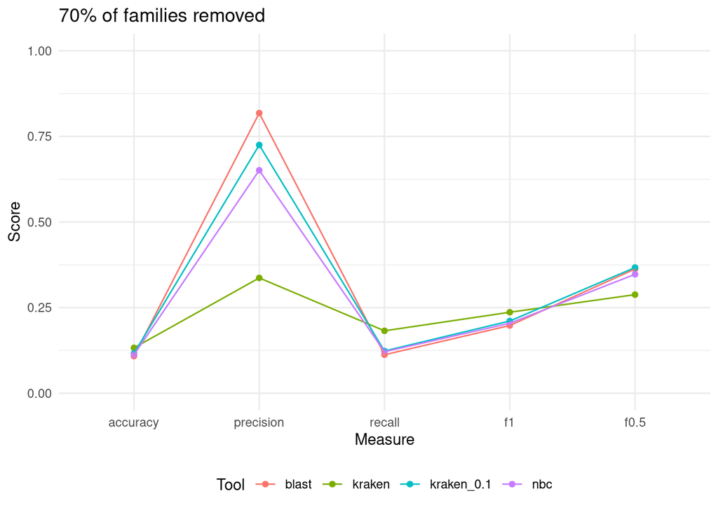

```r
df |> pivot_longer(-names, names_to = 'Measure', values_to='Score') |>
  rename(Tool = names) |>
  ggplot(aes(x = factor(Measure, levels=c('accuracy', 'precision', 'recall', 'f1', 'f0.5')),  color = Tool, fill = Tool, y = Score, group = Tool)) + geom_point() + geom_line() +
  ylim(c(0, 1)) + theme_minimal() + theme(legend.position="bottom") + xlab('Measure') + ggtitle('70% of families removed')
```